# 🔍 TP : Détection de Spam dans des Messages Textuels

#### Dans ce TP, le but était de réussir à détecter si un message est un **spam** ou non, en se basant sur son contenu. Pour ça, j’ai travaillé sur un jeu de données contenant des SMS déjà classés (spam ou ham), et j’ai construit un petit classifieur étape par étape.

#### On commencera par analyser et nettoyer les messages, puis on va extraire quelques **caractéristiques utiles** (comme la longueur du message ou les mots suspects). Ensuite, on testera différents modèles pour voir lequel serait le plus adapté : **Naive Bayes**, **arbre de décision**, et **random forest**.

```python
# Installation des Packages :
!pip install pandas nltk wordcloud matplotlib seaborn spacy scikit-learn
!python -m spacy download fr_core_news_sm
```

## Tâche 1.A :

```python
import pandas as pd
import nltk
import matplotlib.pyplot as plt
import seaborn as sns
from wordcloud import WordCloud
import spacy

nltk.download('punkt')
nltk.download('stopwords')
nltk.download('averaged_perceptron_tagger')

sns.set(style='darkgrid')
```

```python
data = pd.read_csv('SPAM text message 20170820 - Data.csv')  # Remplace par le vrai nom du fichier

data.head()
```

|  | Category | Message |
| --- | --- | --- |
| 0 | ham | Go until jurong point, crazy.. Available only ... |
| 1 | ham | Ok lar... Joking wif u oni... |
| 2 | spam | Free entry in 2 a wkly comp to win FA Cup fina... |
| 3 | ham | U dun say so early hor... U c already then say... |
| 4 | ham | Nah I don't think he goes to usf, he lives aro... |

## Tâche 1.B :

```python
from nltk.tokenize import word_tokenize

data['tokens'] = data['Message'].apply(word_tokenize)

data[['Message', 'tokens']].head()
```

|  | Message | tokens |
| --- | --- | --- |
| 0 | Go until jurong point, crazy.. Available only ... | [Go, until, jurong, point, ,, crazy, .., Avail... |
| 1 | Ok lar... Joking wif u oni... | [Ok, lar, ..., Joking, wif, u, oni, ...] |
| 2 | Free entry in 2 a wkly comp to win FA Cup fina... | [Free, entry, in, 2, a, wkly, comp, to, win, F... |
| 3 | U dun say so early hor... U c already then say... | [U, dun, say, so, early, hor, ..., U, c, alrea... |
| 4 | Nah I don't think he goes to usf, he lives aro... | [Nah, I, do, n't, think, he, goes, to, usf, ,,... |

#### 🔹 Ici j’ai utilisé la fonction `word_tokenize` de la librairie NLTK pour découper chaque message en une liste de mots. J’ai appliqué ça à toute la colonne `Message`, et j’ai stocké le résultat dans une nouvelle colonne appelée `tokens`. Comme ça, chaque ligne contient à la fois le message d’origine et sa version découpée mot par mot. C’est une étape essentielle avant de faire des analyses ou du nettoyage plus poussé.

## Tâche 1.C :

```python
from nltk.corpus import stopwords

stop_words = set(stopwords.words('english'))

data['tokens_clean'] = data['tokens'].apply(lambda mots: [mot for mot in mots if mot.lower() not in stop_words])

data[['Message', 'tokens', 'tokens_clean']].head()
```

|  | Message | tokens | tokens_clean |
| --- | --- | --- | --- |
| 0 | Go until jurong point, crazy.. Available only ... | [Go, until, jurong, point, ,, crazy, .., Avail... | [Go, jurong, point, ,, crazy, .., Available, b... |
| 1 | Ok lar... Joking wif u oni... | [Ok, lar, ..., Joking, wif, u, oni, ...] | [Ok, lar, ..., Joking, wif, u, oni, ...] |
| 2 | Free entry in 2 a wkly comp to win FA Cup fina... | [Free, entry, in, 2, a, wkly, comp, to, win, F... | [Free, entry, 2, wkly, comp, win, FA, Cup, fin... |
| 3 | U dun say so early hor... U c already then say... | [U, dun, say, so, early, hor, ..., U, c, alrea... | [U, dun, say, early, hor, ..., U, c, already, ... |
| 4 | Nah I don't think he goes to usf, he lives aro... | [Nah, I, do, n't, think, he, goes, to, usf, ,,... | [Nah, n't, think, goes, usf, ,, lives, around,... |

#### 🔹 Ici j’ai enlevé les mots qu’on appelle "stopwords", c’est-à-dire les mots très fréquents comme "the", "is", "you"... Ils n’apportent rien de spécial pour notre analyse. Pour ça, j’ai utilisé les stopwords intégrés dans NLTK et j’ai filtré chaque liste de tokens avec un `apply`. Le résultat est stocké dans une nouvelle colonne `tokens_clean` contenant uniquement les mots utiles.

## Tâche 2.A :

```python
from nltk import FreqDist

tous_les_mots = [mot.lower() for message in data['tokens_clean'] for mot in message]

frequences = FreqDist(tous_les_mots)

frequences.most_common(20)
```

```
[('.', 4926),
 (',', 1938),
 ('?', 1550),
 ('!', 1398),
 ('u', 1147),
 ('...', 1146),
 ('&', 919),
 (';', 768),
 (':', 722),
 ('..', 697),
 ('call', 575),
 (')', 499),
 ("'s", 494),
 ('2', 489),
 ("'m", 395),
 ('ur', 391),
 ('get', 386),
 ("n't", 366),
 ('gt', 318),
 ('lt', 316)]
```

#### 🔹 Ici j’ai regroupé tous les mots des messages nettoyés en une seule grande liste. Ensuite j’ai utilisé `FreqDist` de NLTK pour compter combien de fois chaque mot apparaît. Le but, c’est de voir quels mots sont les plus fréquents dans l’ensemble du dataset. J’affiche ici le top 20 des mots qui reviennent le plus souvent dans les messages.

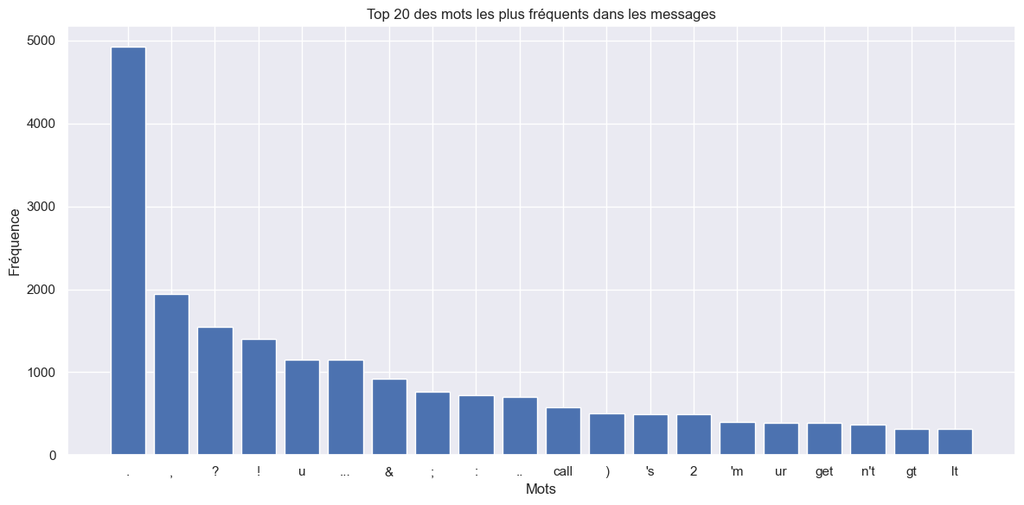

```python
import matplotlib.pyplot as plt

mots_top, freqs_top = zip(*frequences.most_common(20))

plt.figure(figsize=(12, 6))
plt.bar(mots_top, freqs_top)
plt.title("Top 20 des mots les plus fréquents dans les messages")
plt.xlabel("Mots")
plt.ylabel("Fréquence")
plt.tight_layout()
plt.show()
```

#### 🔹 J’ai fait un petit histogramme pour visualiser les mots les plus fréquents. On voit tout de suite quels termes ressortent souvent dans les messages. Ça permet de mieux comprendre les tendances ou répétitions dans les spams (ou les non-spams).

## Tâche 2.B :

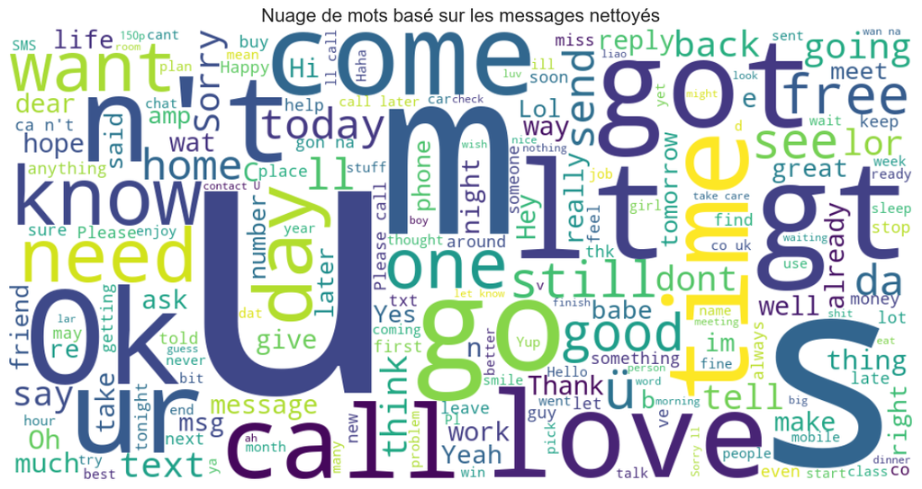

```python
from wordcloud import WordCloud

texte_complet = ' '.join([' '.join(mots) for mots in data['tokens_clean']])

wordcloud = WordCloud(width=1000, height=500, background_color='white').generate(texte_complet)

plt.figure(figsize=(15, 7))
plt.imshow(wordcloud, interpolation='bilinear')
plt.axis('off')
plt.title("Nuage de mots basé sur les messages nettoyés", fontsize=16)
plt.show()
```

#### 🔹 Ici j’ai généré un nuage de mots (`WordCloud`) à partir de tous les mots nettoyés présents dans les messages. Chaque mot est affiché avec une taille proportionnelle à sa fréquence : plus un mot est gros, plus il est fréquent.

## Tâche 3.A :

```python
import nltk
nltk.download('averaged_perceptron_tagger_eng')
```

```
True
```

```python
from nltk import pos_tag

# On choisit un message déjà nettoyé
exemple = data['tokens_clean'].iloc[0]

tags = pos_tag(exemple)
tags
```

```
[('Go', 'VB'),
 ('jurong', 'JJ'),
 ('point', 'NN'),
 (',', ','),
 ('crazy', 'JJ'),
 ('..', 'NNP'),
 ('Available', 'NNP'),
 ('bugis', 'NN'),
 ('n', 'RB'),
 ('great', 'JJ'),
 ('world', 'NN'),
 ('la', 'NN'),
 ('e', 'FW'),
 ('buffet', 'NN'),
 ('...', ':'),
 ('Cine', 'NNP'),
 ('got', 'VBD'),
 ('amore', 'RB'),
 ('wat', 'NN'),
 ('...', ':')]
```

#### 🔹 J’ai sélectionné un message et j’ai appliqué le `PoS tagging` (Part-of-Speech tagging) avec la fonction `pos_tag`. Ça permet d’identifier la nature grammaticale de chaque mot (nom, verbe, adjectif, etc.). L’objectif, c’est de mieux comprendre la structure des messages et éventuellement repérer les mots-clés utiles. Chaque mot est affiché avec son étiquette grammaticale correspondante.

## Tâche 3.B :

```python
!python -m spacy download en_core_web_sm
```

```
     ---------------------------------------- 0.0/12.8 MB ? eta -:--:--
     ------------------ --------------------- 5.8/12.8 MB 35.3 MB/s eta 0:00:01
     --------------------------------------- 12.8/12.8 MB 36.6 MB/s eta 0:00:00
[+] Download and installation successful
You can now load the package via spacy.load('en_core_web_sm')
```

```python
import spacy

nlp = spacy.load("en_core_web_sm")

message = data['Message'].iloc[0]

doc = nlp(message)

for ent in doc.ents:
    print(ent.text, "→", ent.label_)
```

```
jurong point → PERSON
```

#### 🔹 J’ai utilisé le modèle `en_core_web_sm` de spaCy pour détecter les entités nommées dans un message. Ici, il a détecté “jurong point” comme une entité de type `PERSON`, ce qui montre que spaCy identifie les noms propres automatiquement. Ce type d’analyse permettrait par exemple de repérer les entités sensibles dans des messages spam (noms, montants, lieux, etc...).

## Tâche 4.A :

```python
data['message_length'] = data['Message'].apply(len)

spam_words = ['free', 'win', 'urgent', 'prize', 'claim', 'cash', 'now', 'buy', 'click']

data['spam_word_count'] = data['Message'].apply(
    lambda msg: sum(word.lower() in msg.lower() for word in spam_words)
)

data['offer_freq'] = data['Message'].apply(
    lambda msg: msg.lower().split().count('offer')
)

data[['Message', 'message_length', 'spam_word_count', 'offer_freq']].head()
```

|  | Message | message_length | spam_word_count | offer_freq |
| --- | --- | --- | --- | --- |
| 0 | Go until jurong point, crazy.. Available only ... | 111 | 0 | 0 |
| 1 | Ok lar... Joking wif u oni... | 29 | 0 | 0 |
| 2 | Free entry in 2 a wkly comp to win FA Cup fina... | 155 | 2 | 0 |
| 3 | U dun say so early hor... U c already then say... | 49 | 0 | 0 |
| 4 | Nah I don't think he goes to usf, he lives aro... | 61 | 0 | 0 |

🔹 **Extraction des caractéristiques :**

Ces caractéristiques manuelles vont venir compléter les approches de vectorisation classiques et vont pouvoir aider à améliorer la performance du modèle de classification.

## Tâche 4.B :

```python
from sklearn.model_selection import train_test_split
from sklearn.naive_bayes import MultinomialNB
from sklearn.preprocessing import LabelEncoder

X = data[['message_length', 'spam_word_count']]
y = data['Category']

label_encoder = LabelEncoder()
y_encoded = label_encoder.fit_transform(y)

X_train, X_test, y_train, y_test = train_test_split(X, y_encoded, test_size=0.2, random_state=42)

model = MultinomialNB()
model.fit(X_train, y_train)
```

```
MultinomialNB()
```

🔹 **Tâche 4.B – Construction du modèle de classification :**

- J’ai sélectionné deux caractéristiques simples : `message_length` (longueur du message) et `spam_word_count` (nombre de mots suspects).
- Les catégories (`ham`, `spam`) ont été converties en valeurs numériques (`0` pour ham, `1` pour spam) grâce au `LabelEncoder`.
- J’ai ensuite divisé les données en un ensemble d'entraînement (80%) et un ensemble de test (20%) avec `train_test_split`.
- Enfin, j’ai entraîné un modèle **Naive Bayes** (`MultinomialNB`) sur les données d'entraînement.

Ce modèle est maintenant prêt à être testé !

## Tâche 4.C :

```python
from sklearn.metrics import accuracy_score, precision_score, recall_score, f1_score, confusion_matrix

y_pred = model.predict(X_test)

accuracy = accuracy_score(y_test, y_pred)
precision = precision_score(y_test, y_pred)  # Détecter des spams sans se tromper
recall = recall_score(y_test, y_pred)        # Détecter tous les vrais spams
f1 = f1_score(y_test, y_pred)                # compromis entre précision et rappel
conf_matrix = confusion_matrix(y_test, y_pred)

print("Accuracy :", round(accuracy, 3))
print("Precision:", round(precision, 3))
print("Recall   :", round(recall, 3))
print("F1-score :", round(f1, 3))
print("\nMatrice de confusion :\n", conf_matrix)
```

```
Accuracy : 0.888
Precision: 0.833
Recall   : 0.201
F1-score : 0.324

Matrice de confusion :
 [[960   6]
 [119  30]]
```

🔹 **Tâche 4.C – Évaluation du modèle :**

Après avoir entraîné le modèle Naive Bayes, j’ai évalué ses performances sur les données de test.  
J’ai utilisé plusieurs métriques standards :

- **Accuracy** : pourcentage total de bonnes prédictions.
- **Precision** : parmi les messages prédits comme spam, combien sont réellement des spams.
- **Recall** : parmi tous les vrais spams, combien ont été bien détectés.
- **F1-score** : moyenne harmonique entre précision et rappel (équilibre global).
- **Matrice de confusion** : tableau des vraies vs fausses prédictions (utile pour bien visualiser les erreurs).

Ces mesures permettent de juger si le modèle est vraiment fiable pour différencier les spams des messages normaux.

### Analyse des performances du modèle

- **Accuracy : 0.888** → Le modèle a correctement classé environ **89%** des messages. En apparence, c’est plutôt bon.
- **Precision : 0.833** → Quand le modèle prédit "spam", il a raison dans **83%** des cas. Il fait donc peu de **faux positifs**.
- **Recall : 0.201** → Par contre, il ne détecte que **20%** des vrais spams. Beaucoup de spams passent inaperçus (**faux négatifs**).
- **F1-score : 0.324** → Ce score est faible car il dépend à la fois de la précision et du rappel. Ici, c’est le faible rappel qui le pénalise.

### Matrice de confusion

|  | Prédit ham | Prédit spam |
| --- | --- | --- |
| **Réel ham** | 960 | 6 |
| **Réel spam** | 119 | 30 |

**Interprétation** :  
Le modèle est trop conservateur : il préfère classer un message comme "ham" plutôt que de prendre le risque de dire "spam".  
C’est pour ça qu’on a **beaucoup de faux négatifs** (119 messages spam non détectés).

Pour améliorer le **recall**, il faudrait :

- enrichir les **caractéristiques** utilisées (plus de mots-clés, n-grams, etc.),
- ou essayer un autre **modèle de classification** (ex : arbre de décision, SVM…).

#### On peut encore essayer avec d'autres modèles comme par exemple avec un arbre de décision :

```python
from sklearn.tree import DecisionTreeClassifier
from sklearn.metrics import accuracy_score, precision_score, recall_score, f1_score, confusion_matrix

tree_model = DecisionTreeClassifier(random_state=42)
tree_model.fit(X_train, y_train)

y_pred_tree = tree_model.predict(X_test)


print(f"Accuracy : {accuracy_score(y_test, y_pred_tree):.3f}")
print(f"Precision: {precision_score(y_test, y_pred_tree):.3f}")
print(f"Recall   : {recall_score(y_test, y_pred_tree):.3f}")
print(f"F1-score : {f1_score(y_test, y_pred_tree):.3f}")

print("\nMatrice de confusion :")
print(confusion_matrix(y_test, y_pred_tree))
```

```
Accuracy : 0.917
Precision: 0.755
Recall   : 0.557
F1-score : 0.641

Matrice de confusion :
[[939  27]
 [ 66  83]]
```

### Évaluation du modèle : Arbre de Décision

- **Accuracy : 0.917** → Ce modèle a correctement classé environ **92%** des messages, c’est mieux que le Naive Bayes.
- **Precision : 0.755** → Quand il prédit "spam", il a raison **dans 75% des cas**, donc peu de faux positifs.
- **Recall : 0.557** → Il détecte **plus de la moitié des spams**, bien mieux que le Naive Bayes (qui était à 0.20).
- **F1-score : 0.641** → Le compromis entre précision et rappel est bien meilleur ici, donc le modèle est plus équilibré.

### Matrice de confusion

|  | Prédit ham | Prédit spam |
| --- | --- | --- |
| **Réel ham** | 939 | 27 |
| **Réel spam** | 66 | 83 |

**Conclusion** :  
Comparé au Naive Bayes, ce modèle est clairement plus efficace pour détecter les spams.  
Il fait un peu plus d’erreurs sur les "ham", mais il rattrape bien le coup en **repérant beaucoup plus de spams**, ce qui est souvent plus important dans un vrai contexte.

On pourrait même envisager un **Random Forest** ou un **SVM** pour aller encore plus loin, mais l’arbre seul fait déjà le boulot !

#### On peut même essayer un autre modèle de classification une autre fois pour s'assurer de l'efficacité de chacu, d'entre eux, pour cette exemple on utilisera le Random Forest :

```python
from sklearn.ensemble import RandomForestClassifier

# Création et entraînement du modèle Random Forest
rf_model = RandomForestClassifier(random_state=42)
rf_model.fit(X_train, y_train)

# Prédictions
y_pred_rf = rf_model.predict(X_test)

# Évaluation des performances
print(f"Accuracy : {accuracy_score(y_test, y_pred_rf):.3f}")
print(f"Precision: {precision_score(y_test, y_pred_rf):.3f}")
print(f"Recall   : {recall_score(y_test, y_pred_rf):.3f}")
print(f"F1-score : {f1_score(y_test, y_pred_rf):.3f}")

# Matrice de confusion
print("\nMatrice de confusion :")
print(confusion_matrix(y_test, y_pred_rf))
```

```
Accuracy : 0.909
Precision: 0.691
Recall   : 0.570
F1-score : 0.625

Matrice de confusion :
[[928  38]
 [ 64  85]]
```

### Évaluation du modèle Random Forest

- **Accuracy : 0.909**  
  Le modèle a correctement classé 90.9% des messages. C’est une bonne performance globale, signe que le modèle distingue plutôt bien entre spam et ham.
- **Precision : 0.691**  
  Lorsqu’il prédit qu’un message est un spam, il a raison dans environ 69% des cas. Donc peu de faux positifs : il ne confond pas trop les messages normaux avec des spams.
- **Recall : 0.570**  
  Il détecte environ 57% des spams présents dans les données. C’est bien meilleur que le modèle naïf qu’on avait testé au départ (où le rappel était à 20%), donc ici on rate moins de vrais spams.
- **F1-score : 0.625**  
  Ce score combine précision et rappel. Ici, il montre que le modèle est plutôt équilibré dans sa capacité à détecter les spams sans trop se tromper.

#### Matrice de confusion :

|  | Prédit ham | Prédit spam |
| --- | --- | --- |
| **Réel ham** | 928 | 38 |
| **Réel spam** | 64 | 85 |

**Conclusion** :

Le modèle Random Forest offre un bon équilibre entre détection et fiabilité. Il surpasse largement Naive Bayes en termes de rappel, tout en conservant une précision correcte. Idéal pour une première version du filtre anti-spam.

### Comparatif des modèles de classification testés

Durant le TP, j’ai testé trois modèles principaux sur les mêmes features (`message_length` et `spam_word_count`) :

#### Naive Bayes (MultinomialNB)

- **Accuracy** : ~88%
- **Precision** : ~83%
- **Recall** : ~20%
- **F1-score** : ~0.32
- Ce modèle est rapide, simple, mais trop passif. Il préfère éviter les erreurs et laisse passer beaucoup trop de spams.  
  Il a un bon taux de précision mais un très mauvais rappel, donc peu intéressant pour un vrai système anti-spam.

#### Decision Tree

- **Accuracy** : ~91.7%
- **Precision** : ~75%
- **Recall** : ~55%
- **F1-score** : ~0.64
- L’arbre de décision est bien plus équilibré. Il fait un bon boulot pour attraper les spams tout en gardant peu de faux positifs.  
  C’est un modèle plus agressif dans la détection, avec un vrai gain sur le rappel.

### Conclusion générale du TP

L’objectif de ce TP était de construire un petit classifieur anti-spam basé sur des caractéristiques simples extraites des messages.  
J’ai exploré plusieurs modèles de classification (Naive Bayes, arbre de décision, random forest) et j’ai pu comparer leur comportement.

Ce TP m’a permis de comprendre comment extraire manuellement des features à partir de texte, comment préparer les données pour mon modèle de Machine learning. Après cela, tester et comparer plusieurs approches et enfin , surtout interpréter les résultats sans s'arrêter au simple taux de réussite. Tout ça dans le but de comprendre comment fonctionne des outils que l'on peut utiliser tous les jours vu qu'on y est confrontés quotidiennement face à nos écrans !